# Assignment_6

**DTM data를 사용시, RandomForest model은 mtry 값이 10일 때 validation set에 대한 Accuracy가 가장 높았으며 그 때 Accuracy 값은 0.814이다.**

- TF-IDF data

```r
# Accuracy를 저장할 vector 생성
rf_tfidf_Accuracy <- vector()

# TF-IDF 적용 data 사용
# model의 mrty 값을 i의 조건으로 변화시켰을 때, validation set 예측 결과
for (i in seq(1,354,by=20)){
 set.seed(123)
 rf_imdb_tfidf <- randomForest(sentiment~., data = imdb_tfidf_train, ntree = 200, mtry = i)
 rf_pred_tfidf <- predict(rf_imdb_tfidf, newdata=imdb_tfidf_valid, type="class")
 rf_tfidf_cM <- confusionMatrix(rf_pred_tfidf, imdb_tfidf_valid$sentiment, positive = "positive")
 rf_tfidf_Accuracy <- c(rf_tfidf_Accuracy, rf_tfidf_cM$overall[1])
}

# mtry 값에 따른 Accuracy 값 데이터프레임 생성
df3 <- data.frame(mtry = seq(1,354,by=20), Accuracy = rf_tfidf_Accuracy)
df3
```

```
##    mtry Accuracy
## 1     1    0.768
## 2    21    0.791
## 3    41    0.788
## 4    61    0.779
## 5    81    0.780
## 6   101    0.769
## 7   121    0.756
## 8   141    0.759
## 9   161    0.765
## 10  181    0.747
## 11  201    0.755
## 12  221    0.759
## 13  241    0.760
## 14  261    0.760
## 15  281    0.749
## 16  301    0.755
## 17  321    0.755
## 18  341    0.755
```

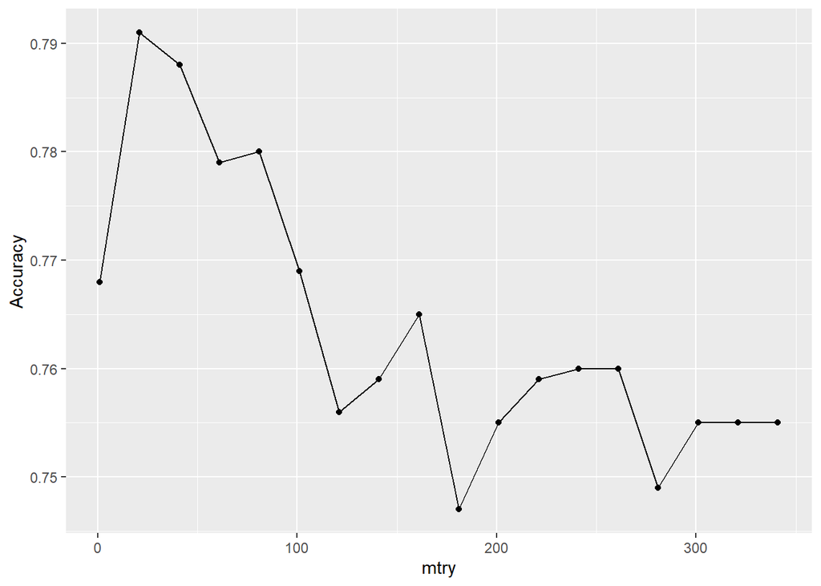

```r
# mtry 값에 따른 Accuracy 값 시각화
rf_plot3 <- ggplot(df3, aes(x=mtry, y=Accuracy)) + geom_point() + geom_line()
rf_plot3
```

```r
# vector 초기화
rf_tfidf_Accuracy <- vector()

# 더 좋은 성능을 가지는 mtry 값을 찾기 위해 가장 Accuracy가 높은 mtry 값 주변 범위로 i 값을 설정하여 한 번 더 반복
for (i in 8:28){
 set.seed(123)
 rf_imdb_tfidf <- randomForest(sentiment~., data = imdb_tfidf_train, ntree = 200, mtry = i)
 rf_pred_tfidf <- predict(rf_imdb_tfidf, newdata=imdb_tfidf_valid, type="class")
 rf_tfidf_cM <- confusionMatrix(rf_pred_tfidf, imdb_tfidf_valid$sentiment, positive = "positive")
 rf_tfidf_Accuracy <- c(rf_tfidf_Accuracy, rf_tfidf_cM$overall[1])
}

# mtry 값에 따른 Accuracy 값 데이터프레임 생성
df4 <- data.frame(mtry = 8:28, Accuracy = rf_tfidf_Accuracy)
df4
```

```
##    mtry Accuracy
## 1     8    0.804
## 2     9    0.798
## 3    10    0.801
## 4    11    0.802
## 5    12    0.793
## 6    13    0.807
## 7    14    0.804
## 8    15    0.794
## 9    16    0.798
## 10   17    0.806
## 11   18    0.803
## 12   19    0.799
## 13   20    0.802
## 14   21    0.791
## 15   22    0.800
## 16   23    0.789
## 17   24    0.798
## 18   25    0.797
## 19   26    0.804
## 20   27    0.792
## 21   28    0.792
```

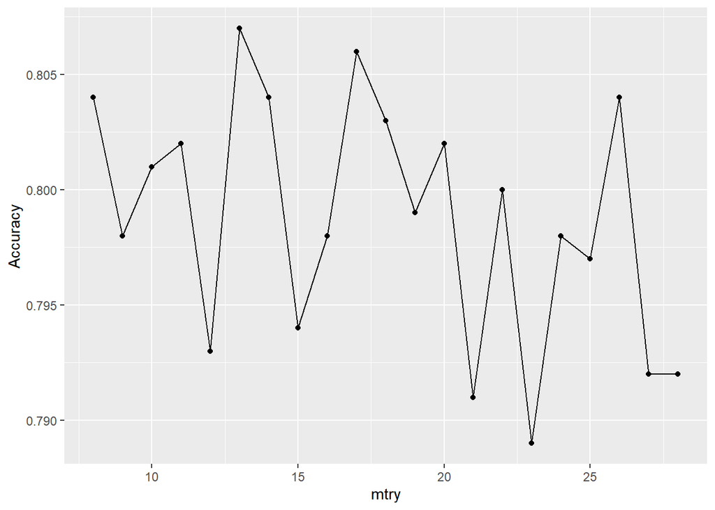

```r
# mtry 값에 따른 Accuracy 값 시각화
rf_plot4 <- ggplot(df4, aes(x=mtry, y=Accuracy)) + geom_point() + geom_line()
rf_plot4
```

**예상대로 Decision tree보다 tree의 수를 더 많이 생성해보기 때문에 성능이 더 좋게 나타났다.**

#### < 최종 결과>

[output not shown]

2. 최종적으로 선택한 모델은 무엇이며 이 모델의 training set accuracy와 test set accuracy는 얼마인가?

```r
# validation set을 training set에 병합하여 최종 training set 생성
final_train <- imdb[1:3000,]

# 최종 test set 생성
final_test <- imdb[3001:10000,]

# 최종 training set을 사용한 feature matrix 생성
final_trainX <- model.matrix(sentiment~., data=final_train)[,-1]
final_trainY <- final_train$sentiment

# 최종 모델로 선정한 logistic regression model에 lasso regularization 적용하여 학습
final_model <- glmnet(x=final_trainX, y=final_trainY, alpha = 1, family="binomial")

# 학습된 최종 모델을 이용하여 training set 예측
final_train_pred <- predict(final_model, s=lasso_model$lambda[35], newx = final_trainX, type = "class")

# training set에 대한 confusion matrix
confusionMatrix(factor(final_train_pred, levels = c("negative", "positive")), final_train$sentiment, positive = "positive")
```

```
## Confusion Matrix and Statistics
##
##           Reference
## Prediction negative positive
##   negative     1253      171
##   positive      239     1337
##
##                Accuracy : 0.8633
##                  95% CI : (0.8505, 0.8754)
##     No Information Rate : 0.5027
##     P-Value [Acc > NIR] : < 2.2e-16
##
##                   Kappa : 0.7266
##
##  Mcnemar's Test P-Value : 0.0009367
##
##             Sensitivity : 0.8866
##             Specificity : 0.8398
##          Pos Pred Value : 0.8484
##          Neg Pred Value : 0.8799
##              Prevalence : 0.5027
##          Detection Rate : 0.4457
##    Detection Prevalence : 0.5253
##       Balanced Accuracy : 0.8632
##
##        'Positive' Class : positive
##
```

```r
# 최종 test set을 사용한 feature matrix 생성
test_imdb <- model.matrix(sentiment~.,final_test)[,-1]

# 학습된 최종 모델을 이용하여 test set 예측
final_test_pred <- predict(final_model, s=lasso_model$lambda[35], newx = test_imdb, type = "class")

# test set에 대한 confusion matrix
confusionMatrix(factor(final_test_pred, levels = c("negative", "positive")), final_test$sentiment, positive = "positive")
```

```
## Confusion Matrix and Statistics
##
##           Reference
## Prediction negative positive
##   negative     2748      579
##   positive      732     2941
##
##                Accuracy : 0.8127
##                  95% CI : (0.8034, 0.8218)
##     No Information Rate : 0.5029
##     P-Value [Acc > NIR] : < 2.2e-16
##
##                   Kappa : 0.6253
##
##  Mcnemar's Test P-Value : 2.693e-05
##
##             Sensitivity : 0.8355
##             Specificity : 0.7897
##          Pos Pred Value : 0.8007
##          Neg Pred Value : 0.8260
##              Prevalence : 0.5029
##          Detection Rate : 0.4201
##    Detection Prevalence : 0.5247
##       Balanced Accuracy : 0.8126
##
##        'Positive' Class : positive
##
```

**학습된 최종 모델로 예측 결과, training set Accuracy는 0.8633, test set Accuracy는 0.8127가 나타났다.**